# Project 1

Sai Praneeth Vupputuri

25/08/2020

Importing the data after setting the working directory and importing readr library

```r
library(readr)
library(dplyr)
setwd("~/Coursera/reproducible research/repdata_data_activity")
activity <- read_csv("activity.csv", na = "NA")
```

Converting date column into the appropriate format and aggregating the data date wise using the aggregate function

```r
activity$date <- as.Date(activity$date, "%Y-%m-%d")
final_data <- aggregate(steps~date, activity,sum)
```

Using the “final_data” dataframe to build a histogram with the base plot system

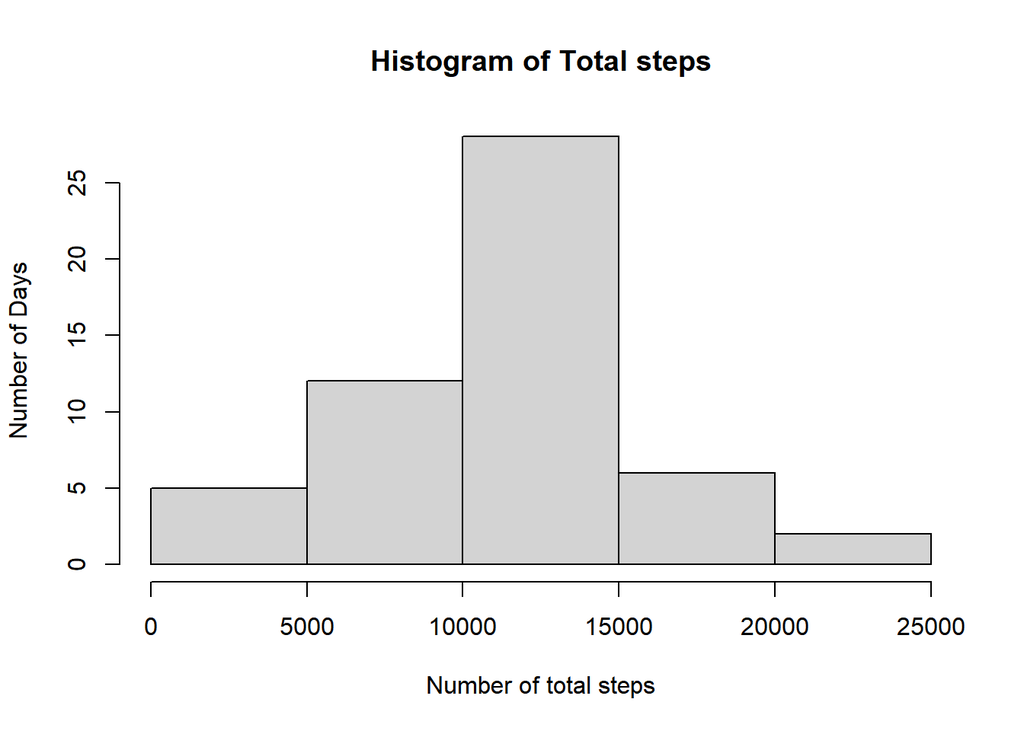

```r
hist(final_data$steps, xlab = "Number of total steps", ylab = "Number of Days", main = "Histogram of Total steps")
```

Displaying the mean of the aggregated dataset

```r
aggregate(steps~date,activity,mean)
```

```
##          date      steps
## 1  2012-10-02  0.4375000
## 2  2012-10-03 39.4166667
## 3  2012-10-04 42.0694444
## 4  2012-10-05 46.1597222
## 5  2012-10-06 53.5416667
## 6  2012-10-07 38.2465278
## 7  2012-10-09 44.4826389
## 8  2012-10-10 34.3750000
## 9  2012-10-11 35.7777778
## 10 2012-10-12 60.3541667
## 11 2012-10-13 43.1458333
## 12 2012-10-14 52.4236111
## 13 2012-10-15 35.2048611
## 14 2012-10-16 52.3750000
```

[output cut: 39 more lines]

Displaying the median of the aggregated dataset

```r
aggregate(steps~date,activity,FUN = "median")
```

```
##          date steps
## 1  2012-10-02     0
## 2  2012-10-03     0
## 3  2012-10-04     0
## 4  2012-10-05     0
## 5  2012-10-06     0
## 6  2012-10-07     0
## 7  2012-10-09     0
## 8  2012-10-10     0
## 9  2012-10-11     0
## 10 2012-10-12     0
## 11 2012-10-13     0
## 12 2012-10-14     0
## 13 2012-10-15     0
## 14 2012-10-16     0
```

[output cut: 39 more lines]

Calculating the mean of steps for each interval

```r
meaninterval <- aggregate(steps~interval,activity, mean)
```

Plotting the mean interval data

[figure not shown]

```r
plot(meaninterval, type = "l", xlab= "Intervals", ylab = "Steps", main = "Mean number of steps for 5 Second Intervals")
```

Finding which 5-minute interval, on average across all the days in the dataset, contains the maximum number of steps?

```r
max <- which.max(meaninterval$steps)
meaninterval[max,]
```

```
##     interval    steps
## 104      835 206.1698
```

As you can see the maximum steps from average is 206 for interval 835

Finding the number of NA values using table function

```r
table(is.na(activity$steps))
```

```
##
## FALSE  TRUE
## 15264  2304
```

As shown abovw, the total number of NA values is 2304

Before we can substitute, I am first separting out the data into two parts, With NA values and without NA values

```r
clean <- activity[!is.na(activity$steps),]
nadata<- activity[is.na(activity$steps),]
```

Then merging the nadata dataframe and meaninterval dataframe

```r
newdata<-merge(nadata, meaninterval, by=c("interval"))
names(newdata) = sub("steps.y", "steps", names(newdata))
newdata$steps.x<- NULL
```

Finally Merging clean dataframe with the mean-populated na dataset

```r
updatedset<- rbind(clean,newdata)
```

Checking if there are still any NA values in the Updated dataset

```r
table(is.na(updatedset$steps))
```

```
##
## FALSE
## 17568
```

The lack of any true values in the table indicates that all missing NA values have been successfully replaced

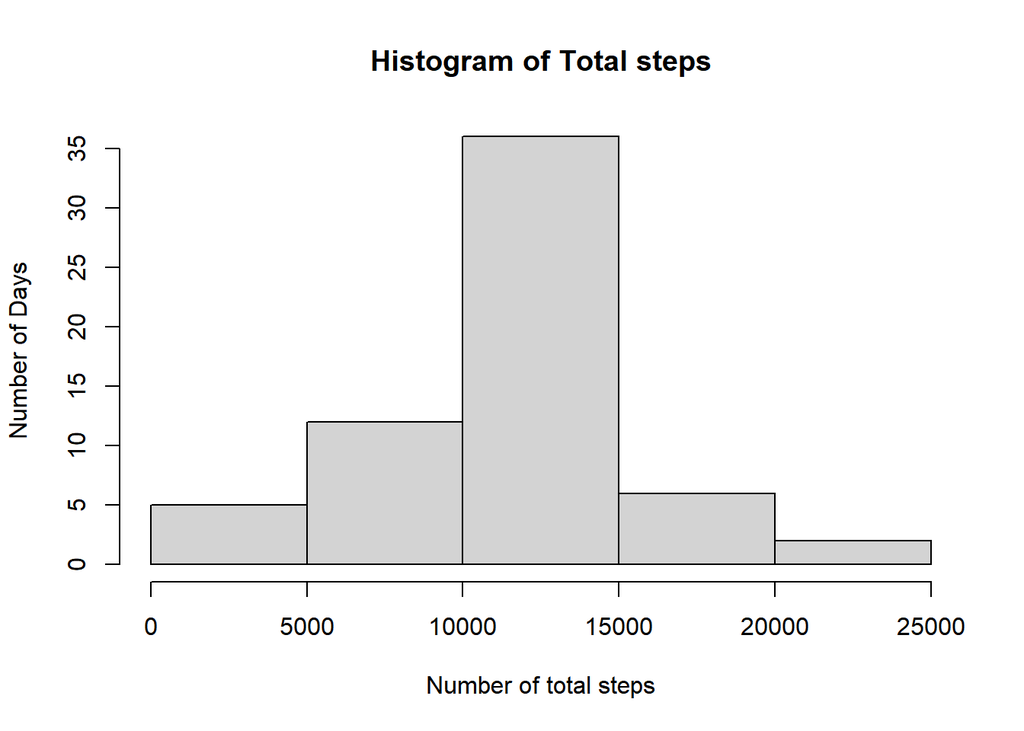

```r
updatedset_final <- aggregate(steps~date, updatedset, sum)
hist(updatedset_final$steps, xlab = "Number of total steps", ylab = "Number of Days", main = "Histogram of Total steps")
```

```r
aggregate(steps~date,updatedset_final,mean)
```

```
##          date    steps
## 1  2012-10-01 10766.19
## 2  2012-10-02   126.00
## 3  2012-10-03 11352.00
## 4  2012-10-04 12116.00
## 5  2012-10-05 13294.00
## 6  2012-10-06 15420.00
## 7  2012-10-07 11015.00
## 8  2012-10-08 10766.19
## 9  2012-10-09 12811.00
## 10 2012-10-10  9900.00
## 11 2012-10-11 10304.00
## 12 2012-10-12 17382.00
## 13 2012-10-13 12426.00
## 14 2012-10-14 15098.00
```

[output cut: 47 more lines]

```r
aggregate(steps~date,updatedset_final,FUN = "median")
```

```
##          date    steps
## 1  2012-10-01 10766.19
## 2  2012-10-02   126.00
## 3  2012-10-03 11352.00
## 4  2012-10-04 12116.00
## 5  2012-10-05 13294.00
## 6  2012-10-06 15420.00
## 7  2012-10-07 11015.00
## 8  2012-10-08 10766.19
## 9  2012-10-09 12811.00
## 10 2012-10-10  9900.00
## 11 2012-10-11 10304.00
## 12 2012-10-12 17382.00
## 13 2012-10-13 12426.00
## 14 2012-10-14 15098.00
```

[output cut: 47 more lines]

Creating a new “day” column and using that to create factor column that will contain weekend and weekday information

```r
updatedset$day <- weekdays(as.Date(updatedset$date))
updatedset$DayCategory <- ifelse(updatedset$day %in% c("Saturday", "Sunday"), "Weekend", "Weekday")
head(updatedset)
```

```
## # A tibble: 6 x 5
##   steps date       interval day     DayCategory
##   <dbl> <date>        <dbl> <chr>   <chr>
## 1     0 2012-10-02        0 Tuesday Weekday
## 2     0 2012-10-02        5 Tuesday Weekday
## 3     0 2012-10-02       10 Tuesday Weekday
## 4     0 2012-10-02       15 Tuesday Weekday
## 5     0 2012-10-02       20 Tuesday Weekday
## 6     0 2012-10-02       25 Tuesday Weekday
```

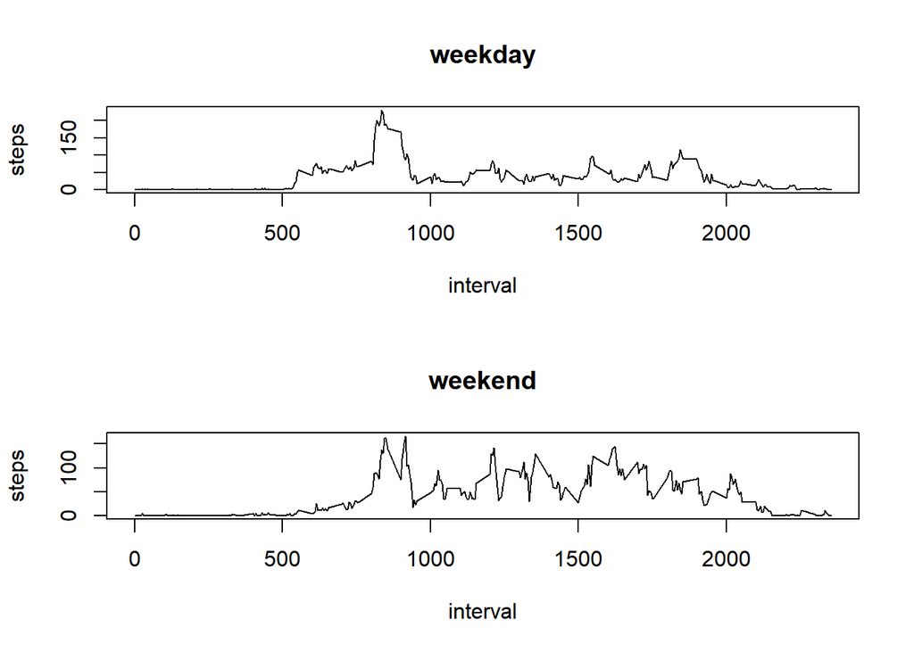

```r
weekend <- filter(updatedset, updatedset$DayCategory == "Weekend")
weekend_final <- aggregate(steps~interval, weekend, mean)
weekday <- filter(updatedset, updatedset$DayCategory == "Weekday")
weekday_final <- aggregate(steps~interval, weekday, mean)
par(mfrow=c(2,1))
plot(weekday_final, type = "l", main = "weekday")
plot(weekend_final, type = "l", main = "weekend")
```